# 重賞レース予測レポート【レース終了】

作成日時: 2026/08/30 19:53:22

☞ [マニュアル(pdf)](https://ryutoro-galois.github.io/keiba-predictor/manual/manual.pdf)

☞ 過去6年の同一レース結果: [2025年](https://ryutoro-galois.github.io/keiba-predictor/report/PredResult_2025y_raceDate_20250831_20250831.html), [2024年](https://ryutoro-galois.github.io/keiba-predictor/report/PredResult_2024y_raceDate_20240824_20240825.html), [2023年](https://ryutoro-galois.github.io/keiba-predictor/report/PredResult_2023y_raceDate_20230826_20230827.html), [2022年](https://ryutoro-galois.github.io/keiba-predictor/report/PredResult_2022y_raceDate_20220828_20220828.html), [2021年](https://ryutoro-galois.github.io/keiba-predictor/report/PredResult_2021y_raceDate_20210828_20210829.html), [2020年](https://ryutoro-galois.github.io/keiba-predictor/report/PredResult_2020y_raceDate_20200829_20200830.html)

☞ 過去4週間の別レース結果: [1週前(8/23)](https://ryutoro-galois.github.io/keiba-predictor/report/PredResult_2026y_raceDate_20260823_20260823.html), [2週前(8/15-16)](https://ryutoro-galois.github.io/keiba-predictor/report/PredResult_2026y_raceDate_20260815_20260816.html), [3週前(8/8-9)](https://ryutoro-galois.github.io/keiba-predictor/report/PredResult_2026y_raceDate_20260808_20260809.html), [4週前(8/2)](https://ryutoro-galois.github.io/keiba-predictor/report/PredResult_2026y_raceDate_20260802_20260802.html)

☞ netkeiba: [新潟記念(GⅢ)](https://race.netkeiba.com/race/result.html?race_id=202604030408&rf=race_submenu), [中京2歳ステークス(GⅢ)](https://race.netkeiba.com/race/result.html?race_id=202607030407&rf=race_submenu)

☞ レース結果(csv): [8/29-30](https://ryutoro-galois.github.io/keiba-predictor/csv/race_result_20260829_20260830.csv)

## 【レース結果(1)】人気と着順の関係

### 【新潟記念(2026/08/30(日))】

【新潟記念(GⅢ)】  
2026/08/30(日), 04_新潟, 芝左外2000m

[interactive chart not shown]

### 【中京2歳ステークス(2026/08/30(日))】

【中京2歳ステークス(GⅢ)】  
2026/08/30(日), 07_中京, 芝1400m

[interactive chart not shown]

## 【レース結果(2)】コーナー通過順位

### 【新潟記念(2026/08/30(日))】

【新潟記念(GⅢ)】  
2026/08/30(日), 04_新潟, 芝左外2000m

[interactive chart not shown]

### 【中京2歳ステークス(2026/08/30(日))】

【中京2歳ステークス(GⅢ)】  
2026/08/30(日), 07_中京, 芝1400m

[interactive chart not shown]

## 0. 推し馬予測 (AI予測)

### 【新潟記念(GⅢ) 2026/08/30(日)】

- 本命(◎): 1-3着内確率(勝負強さ)が1位の馬
- 対抗(◯): 1-3着内確率が2-N位(20%程度以上)の中で予測タイムが最も速い馬
- 3番手(▲): 1-3着内確率が2-N位(20%程度以上)のでダークホース確率が最も高い馬
- 穴: ダークホース確率が上位1-M位(40%程度以上)の中で1-3着内確率が最も高い馬

| 推し馬 | 枠番 | 馬番 | 人気 | オッズ | 馬名 | 騎手 | 調教師 | 予測タイム(sec) | 1_順位 | 1-3着内確率(%) | 2_順位 | ﾀﾞｰｸﾎｰｽ確率(%) | 3_順位 |
| --- | --- | --- | --- | --- | --- | --- | --- | --- | --- | --- | --- | --- | --- |
| 本命(◎) | 3 | 3 | 2 | 3.8 | ロデオドライブ | Ｃ．ルメール | 辻哲英 | 117.5 | 2 | 40.2 | 1 | 0.5 | 11 |
| 対抗(◯) | 5 | 5 | 1 | 3.7 | ゾロアストロ | 岩田望来 | 宮田敬介 | 117.5 | 2 | 25.7 | 3 | 0.7 | 9 |
| 3番手(▲) | 4 | 4 | 4 | 8.3 | ドゥレッツァ | 田辺裕信 | 尾関知人 | 117.6 | 4 | 30.6 | 2 | 2.1 | 8 |
| 穴 | 7 | 9 | 7 | 15.5 | アーバンシック | 三浦皇成 | 武井亮 | 123.0 | 5 | 15.7 | 5 | 60.0 | 1 |

### 【中京2歳ステークス(GⅢ) 2026/08/30(日)】

- 本命(◎): 1-3着内確率(勝負強さ)が1位の馬
- 対抗(◯): 1-3着内確率が2-N位(20%程度以上)の中で予測タイムが最も速い馬
- 3番手(▲): 1-3着内確率が2-N位(20%程度以上)のでダークホース確率が最も高い馬
- 穴: ダークホース確率が上位1-M位(40%程度以上)の中で1-3着内確率が最も高い馬

| 推し馬 | 枠番 | 馬番 | 人気 | オッズ | 馬名 | 騎手 | 調教師 | 予測タイム(sec) | 1_順位 | 1-3着内確率(%) | 2_順位 | ﾀﾞｰｸﾎｰｽ確率(%) | 3_順位 |
| --- | --- | --- | --- | --- | --- | --- | --- | --- | --- | --- | --- | --- | --- |
| 本命(◎) | 7 | 7 | 2 | 4.0 | ビスケットサンド | 北村友一 | 佐藤悠太 | 85.5 | 3 | 31.7 | 1 | 1.2 | 7 |
| 対抗(◯) | 8 | 9 | 1 | 2.1 | ジーティーマイカ | 松山弘平 | 前川恭子 | 80.8 | 1 | 16.9 | 3 | 0.4 | 9 |
| 3番手(▲) | 6 | 6 | 7 | 22.3 | ジャスパートレノ | 中井裕二 | 森秀行 | 82.9 | 2 | 10.4 | 6 | 34.8 | 1 |
| 穴 | 4 | 4 | 4 | 9.5 | シスキンブルーム | 団野大成 | 斉藤崇史 | 89.0 | 5 | 17.4 | 2 | 1.9 | 5 |

## 1. 予測チャート (タイム/勝負強さ)

### 【新潟記念(GⅢ)】

2026/08/30(日), 04_新潟, 芝左外2000m

[interactive chart not shown]

### 【中京2歳ステークス(GⅢ)】

2026/08/30(日), 07_中京, 芝1400m

[interactive chart not shown]

## 2. オッズモニタリング (毎時)

### 【新潟記念】

[interactive chart not shown]

### 【中京2歳ステークス】

[interactive chart not shown]

## 3. 出馬表

### 【新潟記念 2026/08/30(日) 】

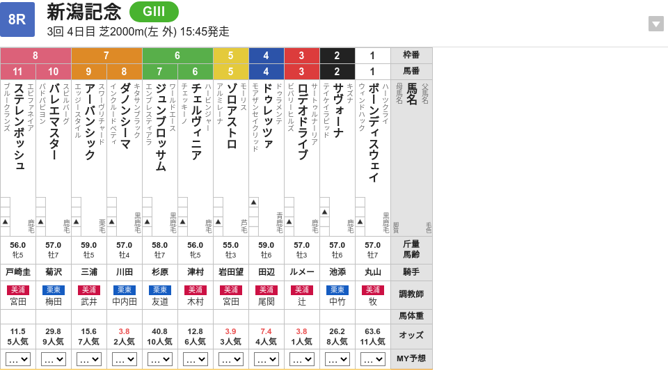

### 【中京2歳ステークス 2026/08/30(日) 】

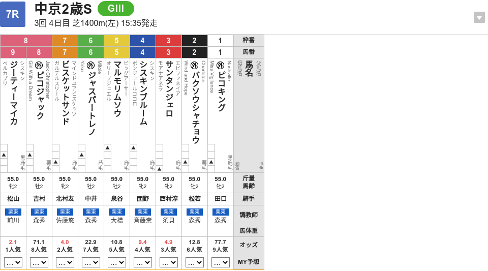

## 4. 単勝予測結果

### 【新潟記念(GⅢ) 2026/08/30(日)】

| 枠番 | 馬番 | 人気 | オッズ | 馬名 | 騎手 | 調教師 | 予測タイム(sec) | 1_順位 | 1-3着内確率(%) | 2_順位 | ﾀﾞｰｸﾎｰｽ確率(%) | 3_順位 |
| --- | --- | --- | --- | --- | --- | --- | --- | --- | --- | --- | --- | --- |
| 1 | 1 | 11 | 62.6 | ボーンディスウェイ | 丸山元気 | 牧光二 | 131.8 | 8 | 4.0 | 9 | 16.4 | 5 |
| 2 | 2 | 8 | 26.1 | サヴォーナ | 池添謙一 | 中竹和也 | 140.2 | 11 | 2.3 | 10 | 32.4 | 4 |
| 3 | 3 | 2 | 3.8 | ロデオドライブ | Ｃ．ルメール | 辻哲英 | 117.5 | 2 | 40.2 | 1 | 0.5 | 11 |
| 4 | 4 | 4 | 8.3 | ドゥレッツァ | 田辺裕信 | 尾関知人 | 117.6 | 4 | 30.6 | 2 | 2.1 | 8 |
| 5 | 5 | 1 | 3.7 | ゾロアストロ | 岩田望来 | 宮田敬介 | 117.5 | 2 | 25.7 | 3 | 0.7 | 9 |
| 6 | 6 | 6 | 12.6 | チェルヴィニア | 津村明秀 | 木村哲也 | 130.9 | 6 | 10.1 | 7 | 2.8 | 6 |
| 6 | 7 | 10 | 40.8 | ジュンブロッサム | 杉原誠人 | 友道康夫 | 135.9 | 10 | 2.1 | 11 | 54.3 | 2 |
| 7 | 8 | 3 | 3.8 | ダノンシーマ | 川田将雅 | 中内田充正 | 117.5 | 2 | 24.6 | 4 | 0.6 | 10 |
| 7 | 9 | 7 | 15.5 | アーバンシック | 三浦皇成 | 武井亮 | 123.0 | 5 | 15.7 | 5 | 60.0 | 1 |
| 8 | 10 | 9 | 29.2 | バレエマスター | 菊沢一樹 | 梅田智之 | 132.6 | 9 | 8.1 | 8 | 44.1 | 3 |

[output cut: 1 more lines]

### 【中京2歳ステークス(GⅢ) 2026/08/30(日)】

| 枠番 | 馬番 | 人気 | オッズ | 馬名 | 騎手 | 調教師 | 予測タイム(sec) | 1_順位 | 1-3着内確率(%) | 2_順位 | ﾀﾞｰｸﾎｰｽ確率(%) | 3_順位 |
| --- | --- | --- | --- | --- | --- | --- | --- | --- | --- | --- | --- | --- |
| 1 | 1 | 9 | 75.8 | ピコキング | 田口貫太 | 森秀行 | 92.8 | 7 | 3.4 | 9 | 19.9 | 3 |
| 2 | 2 | 6 | 12.7 | バクソウシャチョウ | 松若風馬 | 森秀行 | 93.2 | 9 | 10.5 | 5 | 20.4 | 2 |
| 3 | 3 | 3 | 4.9 | サンタンジェロ | 西村淳也 | 須貝尚介 | 93.0 | 8 | 9.7 | 7 | 1.1 | 8 |
| 4 | 4 | 4 | 9.5 | シスキンブルーム | 団野大成 | 斉藤崇史 | 89.0 | 5 | 17.4 | 2 | 1.9 | 5 |
| 5 | 5 | 5 | 10.6 | マルモリムソウ | 泉谷楓真 | 大橋勇樹 | 85.6 | 4 | 16.8 | 4 | 1.4 | 6 |
| 6 | 6 | 7 | 22.3 | ジャスパートレノ | 中井裕二 | 森秀行 | 82.9 | 2 | 10.4 | 6 | 34.8 | 1 |
| 7 | 7 | 2 | 4.0 | ビスケットサンド | 北村友一 | 佐藤悠太 | 85.5 | 3 | 31.7 | 1 | 1.2 | 7 |
| 8 | 8 | 8 | 68.2 | ピコジャック | 吉村誠之助 | 森秀行 | 92.5 | 6 | 3.4 | 8 | 19.5 | 4 |
| 8 | 9 | 1 | 2.1 | ジーティーマイカ | 松山弘平 | 前川恭子 | 80.8 | 1 | 16.9 | 3 | 0.4 | 9 |

## 5. 人気と着順の乖離率推移

### 【新潟記念_1990y_2019y】

[interactive chart not shown]

### 【新潟記念_1990y_2019y】

| No | 開催年 | 不整合率(%) | 頭数 | 人気別着順(1-3位) | 人気別着順(全体) |
| --- | --- | --- | --- | --- | --- |
| 30 | 2019 | 43.7 | 18頭 | 2-6-8 | 2\|6\|8\|11\|3\|14\|4\|12\|15\|1\|5\|13\|9\|16\|17\|10\|18\|7 |
| 29 | 2018 | 45.3 | 13頭 | 1-6-13 | 1\|6\|13\|5\|10\|4\|3\|7\|9\|2\|11\|8\|12 |
| 28 | 2017 | 33.6 | 17頭 | 6-1-12 | 6\|1\|12\|10\|11\|3\|2\|5\|7\|15\|9\|8\|14\|4\|17\|13\|16 |
| 27 | 2016 | 34.5 | 18頭 | 2-1-9 | 2\|1\|9\|7\|4\|6\|16\|5\|11\|14\|12\|17\|15\|10\|13\|3\|18\|8 |
| 26 | 2015 | 76.0 | 18頭 | 6-9-13 | 6\|9\|13\|10\|14\|7\|5\|12\|3\|2\|15\|8\|18\|11\|4\|1\|16\|17 |
| 25 | 2014 | 39.6 | 18頭 | 1-5-3 | 1\|5\|3\|17\|11\|14\|7\|12\|13\|6\|4\|8\|10\|18\|9\|16\|15\|2 |
| 24 | 2013 | 49.6 | 14頭 | 10-8-7 | 10\|8\|7\|3\|1\|13\|12\|14\|2\|6\|5\|9\|11\|4 |
| 23 | 2012 | 45.6 | 18頭 | 7-9-8 | 7\|9\|8\|2\|11\|4\|1\|13\|6\|5\|14\|12\|17\|3\|16\|15\|9\|18 |
| 22 | 2011 | 52.0 | 11頭 | 5-9-3 | 5\|9\|3\|1\|7\|6\|8\|2\|11\|4\|10 |
| 21 | 2010 | 53.3 | 17頭 | 5-10-4 | 5\|10\|4\|2\|3\|1\|6\|15\|7\|12\|16\|17\|8\|13\|14\|11\|9 |

[output cut: 20 more lines]

## 6. 1-3番人気馬の着順分類予測

### 【新潟記念】

| 分類 | 凡例 | 発生確率(%) | 当該レース | 当該レースランク | 直近1年間 |
| --- | --- | --- | --- | --- | --- |
| 8: 1,2,3番人気すべて着外 (8_darkhorse) | * \| * \| * | 21.9 | 0.72 | 0.72 | 0.44 |
| 1: 1番人気のみ (1_pop1) | 1 \| * \| * | 16.2 | 1.17 | 1.17 | 0.00 |
| 4: 1,2番人気のみ (4_pop12) | 1 \| 2 \| * | 15.1 | 0.90 | 0.90 | 0.00 |
| 5: 1,3番人気のみ (5_pop13) | 1 \| 3 \| * | 12.4 | 1.12 | 1.12 | 0.25 |
| 3: 3番人気のみ (3_pop3) | 3 \| * \| * | 10.2 | 0.00 | 0.00 | 0.00 |
| 2: 2番人気のみ (2_pop2) | 2 \| * \| * | 8.6 | 0.77 | 0.77 | 0.00 |
| 6: 2,3番人気のみ (6_pop23) | 2 \| 3 \| * | 8.6 | 0.77 | 0.77 | 0.00 |
| 7: 1,2,3番人気すべて着内 (7_pop123) | 1 \| 2 \| 3 | 7.0 | 1.25 | 1.25 | 0.00 |

## 7. 3連複予測結果

### 【新潟記念(GⅢ) 2026/08/30(日)】

| 分類 | 馬番 | 枠番 | 人気 | 平均予測タイム(sec) | 1-3着内確率(%) | ﾀﾞｰｸﾎｰｽ確率(%) | 馬名 | 騎手 | 調教師 |
| --- | --- | --- | --- | --- | --- | --- | --- | --- | --- |
| 4: 1,2番人気のみ (4_pop12) | 5-3-4 | 5-3-4 | 1-2-4 | 117.53 | 3.16 | 0.00 | ゾロアストロ \| ロデオドライブ \| ドゥレッツァ | 岩田望来 \| Ｃ．ルメール \| 田辺裕信 | 宮田敬介 \| 辻哲英 \| 尾関知人 |
| 6: 2,3番人気のみ (6_pop23) | 3-8-4 | 3-7-4 | 2-3-4 | 117.53 | 3.03 | 0.00 | ロデオドライブ \| ダノンシーマ \| ドゥレッツァ | Ｃ．ルメール \| 川田将雅 \| 田辺裕信 | 辻哲英 \| 中内田充正 \| 尾関知人 |
| 7: 1,2,3番人気すべて着内 (7_pop123) | 5-3-8 | 5-3-7 | 1-2-3 | 117.50 | 2.54 | 0.00 | ゾロアストロ \| ロデオドライブ \| ダノンシーマ | 岩田望来 \| Ｃ．ルメール \| 川田将雅 | 宮田敬介 \| 辻哲英 \| 中内田充正 |
| 5: 1,3番人気のみ (5_pop13) | 5-8-4 | 5-7-4 | 1-3-4 | 117.53 | 1.94 | 0.00 | ゾロアストロ \| ダノンシーマ \| ドゥレッツァ | 岩田望来 \| 川田将雅 \| 田辺裕信 | 宮田敬介 \| 中内田充正 \| 尾関知人 |
| 2: 2番人気のみ (2_pop2) | 3-4-9 | 3-4-7 | 2-4-7 | 119.37 | 1.93 | 0.01 | ロデオドライブ \| ドゥレッツァ \| アーバンシック | Ｃ．ルメール \| 田辺裕信 \| 三浦皇成 | 辻哲英 \| 尾関知人 \| 武井亮 |
| 4: 1,2番人気のみ (4_pop12) | 5-3-9 | 5-3-7 | 1-2-7 | 119.33 | 1.62 | 0.00 | ゾロアストロ \| ロデオドライブ \| アーバンシック | 岩田望来 \| Ｃ．ルメール \| 三浦皇成 | 宮田敬介 \| 辻哲英 \| 武井亮 |
| 6: 2,3番人気のみ (6_pop23) | 3-8-9 | 3-7-7 | 2-3-7 | 119.33 | 1.55 | 0.00 | ロデオドライブ \| ダノンシーマ \| アーバンシック | Ｃ．ルメール \| 川田将雅 \| 三浦皇成 | 辻哲英 \| 中内田充正 \| 武井亮 |
| 2: 2番人気のみ (2_pop2) | 3-4-11 | 3-4-8 | 2-4-5 | 122.13 | 1.39 | 0.00 | ロデオドライブ \| ドゥレッツァ \| ステレンボッシュ | Ｃ．ルメール \| 田辺裕信 \| 戸崎圭太 | 辻哲英 \| 尾関知人 \| 宮田敬介 |
| 2: 2番人気のみ (2_pop2) | 3-4-6 | 3-4-6 | 2-4-6 | 122.00 | 1.24 | 0.00 | ロデオドライブ \| ドゥレッツァ \| チェルヴィニア | Ｃ．ルメール \| 田辺裕信 \| 津村明秀 | 辻哲英 \| 尾関知人 \| 木村哲也 |
| 1: 1番人気のみ (1_pop1) | 5-4-9 | 5-4-7 | 1-4-7 | 119.37 | 1.23 | 0.01 | ゾロアストロ \| ドゥレッツァ \| アーバンシック | 岩田望来 \| 田辺裕信 \| 三浦皇成 | 宮田敬介 \| 尾関知人 \| 武井亮 |

[output cut: 155 more lines]

### 【中京2歳ステークス(GⅢ) 2026/08/30(日)】

| 分類 | 馬番 | 枠番 | 人気 | 平均予測タイム(sec) | 1-3着内確率(%) | ﾀﾞｰｸﾎｰｽ確率(%) | 馬名 | 騎手 | 調教師 |
| --- | --- | --- | --- | --- | --- | --- | --- | --- | --- |
| 4: 1,2番人気のみ (4_pop12) | 9-7-4 | 8-7-4 | 1-2-4 | 85.10 | 0.93 | 0.00 | ジーティーマイカ \| ビスケットサンド \| シスキンブルーム | 松山弘平 \| 北村友一 \| 団野大成 | 前川恭子 \| 佐藤悠太 \| 斉藤崇史 |
| 2: 2番人気のみ (2_pop2) | 7-4-5 | 7-4-5 | 2-4-5 | 86.70 | 0.93 | 0.00 | ビスケットサンド \| シスキンブルーム \| マルモリムソウ | 北村友一 \| 団野大成 \| 泉谷楓真 | 佐藤悠太 \| 斉藤崇史 \| 大橋勇樹 |
| 4: 1,2番人気のみ (4_pop12) | 9-7-5 | 8-7-5 | 1-2-5 | 83.97 | 0.90 | 0.00 | ジーティーマイカ \| ビスケットサンド \| マルモリムソウ | 松山弘平 \| 北村友一 \| 泉谷楓真 | 前川恭子 \| 佐藤悠太 \| 大橋勇樹 |
| 2: 2番人気のみ (2_pop2) | 7-4-2 | 7-4-2 | 2-4-6 | 89.23 | 0.58 | 0.00 | ビスケットサンド \| シスキンブルーム \| バクソウシャチョウ | 北村友一 \| 団野大成 \| 松若風馬 | 佐藤悠太 \| 斉藤崇史 \| 森秀行 |
| 2: 2番人気のみ (2_pop2) | 7-4-6 | 7-4-6 | 2-4-7 | 85.80 | 0.57 | 0.01 | ビスケットサンド \| シスキンブルーム \| ジャスパートレノ | 北村友一 \| 団野大成 \| 中井裕二 | 佐藤悠太 \| 斉藤崇史 \| 森秀行 |
| 4: 1,2番人気のみ (4_pop12) | 9-7-2 | 8-7-2 | 1-2-6 | 86.50 | 0.56 | 0.00 | ジーティーマイカ \| ビスケットサンド \| バクソウシャチョウ | 松山弘平 \| 北村友一 \| 松若風馬 | 前川恭子 \| 佐藤悠太 \| 森秀行 |
| 2: 2番人気のみ (2_pop2) | 7-5-2 | 7-5-2 | 2-5-6 | 88.10 | 0.56 | 0.00 | ビスケットサンド \| マルモリムソウ \| バクソウシャチョウ | 北村友一 \| 泉谷楓真 \| 松若風馬 | 佐藤悠太 \| 大橋勇樹 \| 森秀行 |
| 4: 1,2番人気のみ (4_pop12) | 9-7-6 | 8-7-6 | 1-2-7 | 83.07 | 0.56 | 0.00 | ジーティーマイカ \| ビスケットサンド \| ジャスパートレノ | 松山弘平 \| 北村友一 \| 中井裕二 | 前川恭子 \| 佐藤悠太 \| 森秀行 |
| 2: 2番人気のみ (2_pop2) | 7-5-6 | 7-5-6 | 2-5-7 | 84.67 | 0.56 | 0.01 | ビスケットサンド \| マルモリムソウ \| ジャスパートレノ | 北村友一 \| 泉谷楓真 \| 中井裕二 | 佐藤悠太 \| 大橋勇樹 \| 森秀行 |
| 6: 2,3番人気のみ (6_pop23) | 7-3-4 | 7-3-4 | 2-3-4 | 89.17 | 0.53 | 0.00 | ビスケットサンド \| サンタンジェロ \| シスキンブルーム | 北村友一 \| 西村淳也 \| 団野大成 | 佐藤悠太 \| 須貝尚介 \| 斉藤崇史 |

[output cut: 74 more lines]

## 8. 直近の全レース情報

| No | 日付 | 競馬場 | R | 発走 | レース名 | 距離 | 頭数 | URL(netkeiba) |
| --- | --- | --- | --- | --- | --- | --- | --- | --- |
| 1 | 2026/08/30(日) | 04_新潟 | 8R |  | 新潟記念 | 0 | 11頭 | https://race.netkeiba.com/race/shutuba.html?race_id=202604030408&amp;rf=race_list |
| 2 | 2026/08/30(日) | 07_中京 | 7R | . | 中京2歳ステークス | 0 | 9頭 | https://race.netkeiba.com/race/shutuba.html?race_id=202607030407&amp;rf=race_list |